# Analysis of Brazilian Fuel

Gal Fudim

5/18/2020

# Introduction

In this tutorial I will walk a user through the entire data science pipeline. I will start with data curation, parsing, and management. Then, I will perform exploratory data analysis, followed by machine learning to provide further analysis. Finally, I will curate a conclusive message covering the insights I learned during this tutorial.

I chose to examine data about Brazilian fuel. Brazilian fuel markets are very interesting in the status quo. As the Bolsonaro administration seeks to increase its power in the Latin American fuel market, Brazilian fuel production has seen sharp increases in the last few years. Analyzing this trend on a closer level has important contributions to data science and to geopolitics within the region. As fuel markets tend to be influenced by a variety of confounding variables, breaking down the data set and examining it part by part reveals that location and fuel type have a high impact on average fuel prices. Geopolitically, the rise of Brazilian fuel coincides with the collapse of the Venezuelan fuel sector, as United States sanctions on the public sector of Venezuela have resulted in a more than 30% reduction in output, creating a vacuum in the South American fuel market that President Jair Bolsonaro hopes to fill.

The data I will be using in this tutorial comes from the National Agency of Petroleum, Natural Gas and Biofuels. The ANP (as it is known in Portuguese) is the federal government agency responsible for the regulation of the Brazilian fuel sector. The ANP releases weekly reports of gas, diesel, and other fuel prices used in transportation across the country. The specific data set I chose to use details the average price of a liter of gas, the number of gas stations analyzed, and other information grouped by regions and states across the country. The data set spans entities from 2004 to 2019. I downloaded the data set from Kaggle, and it is originally available on the ANP website. Both are linked below:

Some of my initial questions about this data set included:

- Is there a relationship between which states increase fuel prices in a region and which do not?
- Which states are the most inexpensive (or most expensive) for different types of fuels?
- Is average price affected by geographical factors, such as region and state?

## References

**Preliminary reading:** [here](https://www.nytimes.com/2020/02/08/world/americas/venezuela-oil-maduro.html)

**Minerals Yearbook - Area Reports:** here

**Original data source:** [here](http://www.anp.gov.br/precos-e-defesa-da-concorrencia/precos/levantamento-de-precos/serie-historica-do-levantamento-de-precos-e-de-margens-de-comercializacao-de-combustiveis)

**Kaggle data repository:** [here](https://www.kaggle.com/matheusfreitag/gas-prices-in-brazil)

# Data Curation, Parsing, and Management

### Required Libraries

I will be using the following R libraries in my analysis:

- tidyverse
- dplyr
- ggplot2

### Data

I downloaded the data set as a TSV (tab-separated values) file. I read it into a data frame.

```r
data <- read.table(file="gas_prices.tsv", sep="\t", header=TRUE)
```

Then, I dropped irrelevant columns from the data set (such as the unique ID of each entity in the data set). I also renamed column names and entity values from Portuguese to English for clarity.

```r
data <- data[-c(1:3, 8, 15:19)]
colnames(data) <- c("region", "state", "product_type", "num_stations_analyzed", "mean_price", "std_dev", "min_price", "max_price", "mean_price_margin", "variation", "month", "year")
data <- data[c(11:12, 1:10)]
data$region <- gsub("CENTRO OESTE", "MIDWEST", data$region)
data$region <- gsub("NORDESTE", "NORTHEAST", data$region)
data$region <- gsub("NORTE", "NORTH", data$region)
data$region <- gsub("SUDESTE", "SOUTHEAST", data$region)
data$region <- gsub("SUL", "SOUTH", data$region)
data$product_type <- gsub("ETANOL HIDRATADO", "ETHANOL", data$product_type)
data$product_type <- gsub("GASOLINA COMUM", "GASOLINE", data$product_type)
data$product_type <- gsub("ÓLEO DIESEL", "DIESEL", data$product_type)
data$product_type <- gsub("ÓLEO DIESEL S10", "DIESEL S10", data$product_type)
data$region <- as.factor(data$region)

head(data)
```

```
##   month year    region              state product_type num_stations_analyzed
## 1     5 2004   MIDWEST   DISTRITO FEDERAL      ETHANOL                   127
## 2     5 2004   MIDWEST              GOIAS      ETHANOL                   387
## 3     5 2004   MIDWEST        MATO GROSSO      ETHANOL                   192
## 4     5 2004   MIDWEST MATO GROSSO DO SUL      ETHANOL                   162
## 5     5 2004 NORTHEAST            ALAGOAS      ETHANOL                   103
## 6     5 2004 NORTHEAST              BAHIA      ETHANOL                   408
##   mean_price std_dev min_price max_price mean_price_margin variation
## 1      1.288   0.016     1.190     1.350             0.463     0.012
## 2      1.162   0.114     0.890     1.449             0.399     0.098
## 3      1.389   0.097     1.180     1.760             0.419     0.070
## 4      1.262   0.070     1.090     1.509             0.432     0.055
## 5      1.181   0.078     1.050     1.400              0.24     0.066
## 6      1.383   0.132     0.999     2.050             0.426     0.095
```

# Exploratory Data Analysis

After cleaning the data set, I checked for missing values.

```r
missing <- summarize_all(data, list(~sum(is.na(.))/n()))
missing
```

```
##   month year region state product_type num_stations_analyzed mean_price std_dev
## 1     0    0      0     0            0                     0          0       0
##   min_price max_price mean_price_margin variation
## 1         0         0                 0         0
```

APN seems to be very careful about inputting their data. It appears the data set has no missing values. Had there been missing values, I would have needed to:

- Entirely remove the entity containing missing values,
- Encode the missing values as missing (by designating them as NA or false), or
- Imputate the missing values (assign them values based on my other inferences on values)

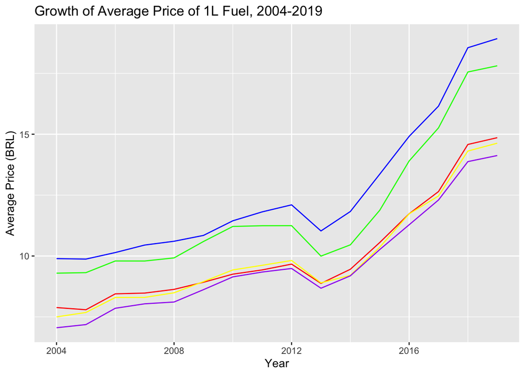

```r
midwest <-
  data %>%
  select(year, mean_price, region) %>%
  filter(region=="MIDWEST") %>%
  group_by(year) %>%
  summarize(mean_price=mean(mean_price))

north <-
  data %>%
  select(year, mean_price, region) %>%
  filter(region=="NORTH") %>%
  group_by(year) %>%
  summarize(mean_price=mean(mean_price))

northeast <-
  data %>%
  select(year, mean_price, region) %>%
  filter(region=="NORTHEAST") %>%
  group_by(year) %>%
  summarize(mean_price=mean(mean_price))

south <-
  data %>%
  select(year, mean_price, region) %>%
  filter(region=="SOUTH") %>%
  group_by(year) %>%
  summarize(mean_price=mean(mean_price))

southeast <-
  data %>%
  select(year, mean_price, region) %>%
  filter(region=="SOUTHEAST") %>%
  group_by(year) %>%
  summarize(mean_price=mean(mean_price))

region_plot <-
  ggplot() +
  geom_line(data=midwest, aes(y=mean_price, x=year), color="green") +
  geom_line(data=north, aes(y=mean_price, x=year), color="blue") +
  geom_line(data=northeast, aes(y=mean_price, x=year), color="red") +
  geom_line(data=south, aes(y=mean_price, x=year), color="yellow") +
  geom_line(data=southeast, aes(y=mean_price, x=year), color="purple") +
  labs(x="Year", y="Average Price (BRL)", title="Growth of Average Price of 1L Fuel, 2004-2019")

region_plot
```

Next, I wanted to see how the different regions compared to each other in terms of average fuel prices. The NORTH and MIDWEST regions were a little more expensive than the other regions, which were clustered around the same average fuel price.

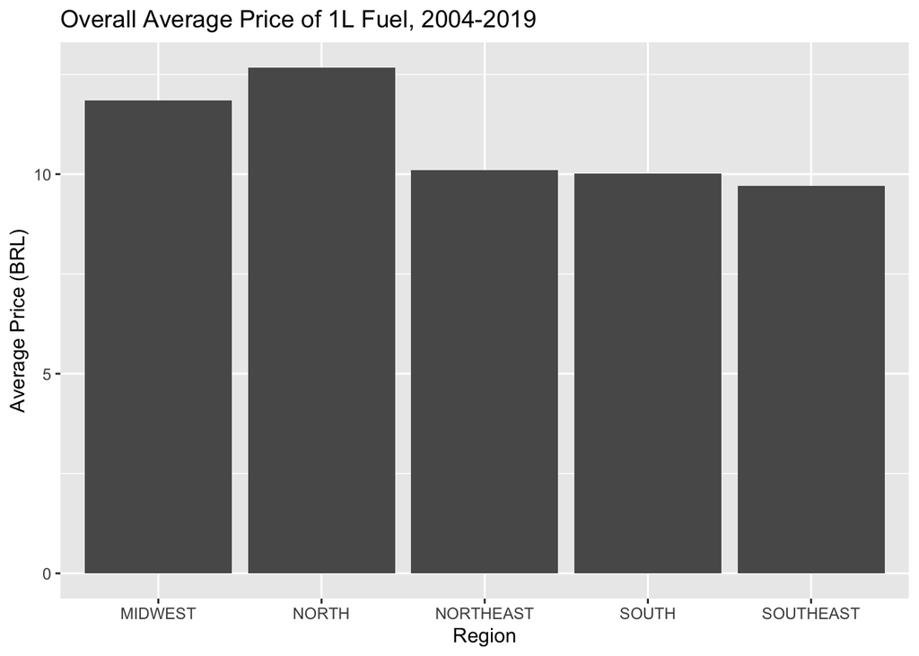

```r
data %>%
  group_by(region) %>%
  summarize(mean_price=mean(mean_price)) %>%
  ggplot(mapping=aes(x=region, y=mean_price)) +
  geom_bar(stat="identity") +
  labs(x="Region", y="Average Price (BRL)", title="Overall Average Price of 1L Fuel, 2004-2019")
```

# Machine Learning

For the machine learning component of the data science pipeline, I chose to focus on the third of my three initial questions. I wanted to investigate whether there is a relationship between the different regions of Brazil, the states in Brazil, fuel type, and the changes in fuel prices. I decided to run a multiple linear regression model. I regressed mean_price on region, state, and fuel type. I fit the predictive model as follows:

```r
# Partitioning the entities into training and validation sets
set.seed(12345)
rowindex <- sample(1:nrow(data), .5*nrow(data), replace=F)
training.data <- data[rowindex,]
validation.data <- data[-rowindex,]

# Running a multiple linear regression model for mean_price on relevant predictors
train.fit <- lm(mean_price~region+state+product_type, data=training.data)
valid.predict <- predict(train.fit, validation.data)
summary(train.fit)
```

```
##
## Call:
## lm(formula = mean_price ~ region + state + product_type, data = training.data)
##
## Residuals:
##     Min      1Q  Median      3Q     Max
## -15.634  -0.953  -0.018   0.647  52.370
##
## Coefficients: (4 not defined because of singularities)
##                          Estimate Std. Error t value Pr(>|t|)
## (Intercept)               3.08358    0.13698  22.512  < 2e-16 ***
## regionNORTH               0.66583    0.18836   3.535 0.000408 ***
## regionNORTHEAST          -1.16685    0.18005  -6.481 9.21e-11 ***
## regionSOUTH              -0.77892    0.17861  -4.361 1.30e-05 ***
## regionSOUTHEAST          -1.54113    0.17870  -8.624  < 2e-16 ***
## stateALAGOAS             -0.14766    0.18104  -0.816 0.414736
## stateAMAPA               -0.13833    0.19995  -0.692 0.489049
## stateAMAZONAS            -2.15813    0.19302 -11.181  < 2e-16 ***
## stateBAHIA               -0.37571    0.17903  -2.099 0.035857 *
## stateCEARA                0.51117    0.17959   2.846 0.004425 **
## stateDISTRITO FEDERAL    -0.39944    0.19057  -2.096 0.036087 *
## stateESPIRITO SANTO       0.11894    0.17976   0.662 0.508206
## stateGOIAS               -1.02879    0.18817  -5.467 4.59e-08 ***
## stateMARANHAO             0.43394    0.19028   2.281 0.022581 *
## stateMATO GROSSO          1.52892    0.18154   8.422  < 2e-16 ***
## stateMATO GROSSO DO SUL        NA         NA      NA       NA
## stateMINAS GERAIS         0.66266    0.17905   3.701 0.000215 ***
## statePARA                -1.37446    0.19663  -6.990 2.78e-12 ***
## statePARAIBA             -0.36279    0.17897  -2.027 0.042660 *
## statePARANA              -0.19065    0.17835  -1.069 0.285093
## statePERNAMBUCO          -0.51505    0.18096  -2.846 0.004426 **
## statePIAUI                0.20618    0.19002   1.085 0.277909
## stateRIO DE JANEIRO       0.17161    0.17897   0.959 0.337627
## stateRIO GRANDE DO NORTE  0.08534    0.18087   0.472 0.637069
## stateRIO GRANDE DO SUL   -0.12189    0.17878  -0.682 0.495393
## stateRONDONIA            -0.52464    0.19768  -2.654 0.007958 **
## stateRORAIMA             -0.13664    0.19854  -0.688 0.491303
## stateSANTA CATARINA            NA         NA      NA       NA
## stateSAO PAULO                 NA         NA      NA       NA
## stateSERGIPE                   NA         NA      NA       NA
## stateTOCANTINS            0.12923    0.19599   0.659 0.509677
## product_typeDIESEL S10    0.71601    0.10436   6.861 6.93e-12 ***
## product_typeETHANOL      -0.09478    0.08055  -1.177 0.239321
## product_typeGASOLINE      0.62286    0.08078   7.710 1.28e-14 ***
## product_typeGLP          42.11709    0.08057 522.712  < 2e-16 ***
## product_typeGNV          -0.17733    0.09418  -1.883 0.059714 .
## ---
## Signif. codes:  0 '***' 0.001 '**' 0.01 '*' 0.05 '.' 0.1 ' ' 1
##
## Residual standard error: 5.86 on 53379 degrees of freedom
## Multiple R-squared:  0.8915, Adjusted R-squared:  0.8914
## F-statistic: 1.414e+04 on 31 and 53379 DF,  p-value: < 2.2e-16
```

From the predictive model, we can see that the MIDWEST and NORTH regions have a significant positive effect on our average price of fuel. Meanwhile, fuel appears to be less expensive in the NORTHEAST, SOUTH, and SOUTHEAST regions (portrayed by the negative coefficients). Interestingly enough, the NORTHEAST region, although geographically distant from major fuel production spots, appears to have similar fuel prices to those of the SOUTH and SOUTHEAST regions. One potential explanation for this could be the heightened coastal presence of the NORTHEAST region. Fuel in the MIDWEST and NORTH regions can only be transported by land, whereas fuel from the SOUTH and SOUTHEAST regions can reach the NORTHEAST through both land and sea.The relevance of states is split pretty evenly; approximately half of them have increased fuel prices, while the other half have decreased fuel prices. Future work could include seeing if the states where fuel prices tend to be higher are directly correlated to the regions where the fuel prices are higher. Lastly, we can see that GNV and ETHANOL are the two least expensive fuels, whereas GLP is an outlier in that it drastically drives up fuel costs.

# Conclusion

Analyzing this data set is important for recognizing the implications of the fuel market on the Brazilian and global economies. Given that Brazil is a key power player in South American fuel distribution, understanding the makeup of Brazilian fuel exports is essential for anyone interested in uncovering the economic trends surrounding Latin America. Moreover, the data set and the resulting regional differences in fuel costs reveals much about the supply chains within Brazil and their ineffectiveness. The majority of Brazilian fuel is mined in the southeastern region of Rio de Janeiro and the southern Campos Basin. This can be seen in the fuel prices of the country; southern areas experience the lowest fuel prices in the country, while northern regions face mounting fuel prices as the costs to transport fuel across the country increase.